# 12. Extended topics

## Resources

- reading:
  - end of BDA3 ch. 4
  - optional: BDA3 ch. 8, 14-18, 21
- lectures:
  - [‘12.1 Frequency evaluation, hypothesis testing and variable selection’](https://aalto.cloud.panopto.eu/Panopto/Pages/Viewer.aspx?id=e998b5dd-bf8e-42da-9f7c-ab1700ca2702)
  - [‘12.2 Overview of modeling data collection, BDA3 Ch 8, linear models, BDA Ch 14-18, lasso, horseshoe and Gaussian processes, BDA3 Ch 21’](https://aalto.cloud.panopto.eu/Panopto/Pages/Viewer.aspx?id=c43c862a-a5a4-45da-9b27-ab1700e12012)
- slides

## Notes

### Lecture 12.1 Frequency evaluation, hypothesis testing and variable selection

- Bayesian vs. Frequentist
  - Bayesian theory has epistemic and aleatory probabilities
  - Frequency evaluations focus on frequency properties given aleatoric repetition of an observation and modeling
- on “null hypothesis testing”:
  - often inappropriate to test the probability that a value is 0
    - for continuous data, the probability of a single value is always 0
    - “region of practical equivalence” (ROPE) is another option
  - best to focus on describing the full posterior
    - e.g. amount of the posterior greater than or less than an important value
    - e.g. where most of the posterior density is (89% or 95% HDI)
- be careful about only looking at marginal posteriors, too
  - joint posterior distributions may be informative
  - e.g. height and weight variables in beta-blocker model are highly correlated; both marginals overlap 0, but joint does not
- most common statistical tests are linear models
  - longer list with more illustrations: https://lindeloev.github.io/tests-as-linear

| classical test | Bayesian equivalent | in ‘rstanarm’ |
| --- | --- | --- |
| t-test | mean of data | `stan_glm(y ~ 1)` |
| paired t-test | mean of diffs | `stan_glm((y1 - y2) ~ 1)` |
| Pearson correlation | linear model | `stan_glm(y ~ 1 + x)` |
| two-sample t-test | group means | `stan_glm(y ~ 1 + gid)` |
| ANOVA | hierarchical model | `stan_glm(y ~ 1 + (1\|gid))` |

### Lecture 12.2 Overview of modeling data collection, BDA3 Ch 8, linear models, BDA Ch 14-18, lasso, horseshoe and Gaussian processes, BDA3 Ch 21

- LASSO and Bayesian LASSO
  - Bayesian LASSO uses Laplace distribution as a prior
  - is equivalent to L1 penalty in MLE LASSO, but because we still integrate over the entire posterior, it does not have the same “sparsifying” effect
  - therefore, Bayesian LASSO is empirically worse than MLE LASSO
  - final thought: best to separate the process of prior selection, posterior inference, and decision analysis
  - **regularized horseshoe prior** a better choice if you have prior information that only some of the covariates are informative

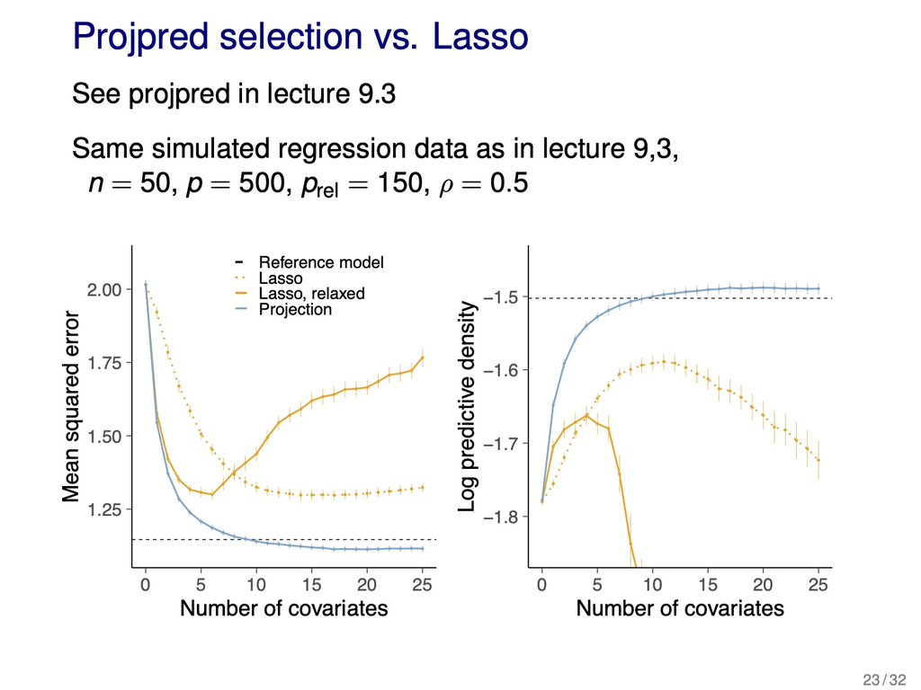

projpred selection vs LASSO